# Community Composition & Comparative Metagenomic Analyses Examples

Author

Joe Boktor

Published

October 25, 2023

Load libraries into environment

```r
cran_packages <-
  c("vegan",
    "usedist"
    )

missing_cran_packages <-
  cran_packages[!(cran_packages %in% installed.packages()[, "Package"])]

if (length(missing_cran_packages)) {
  install.packages(missing_cran_packages)
}

# installing missing Bioconductor specific packages
bioc_packages <- c(
 "microbiomeMarker",
 "SIAMCAT"
)
missing_bioc_packages <-
  bioc_packages[!(bioc_packages %in% installed.packages()[, "Package"])]

if (length(missing_bioc_packages)) {
  BiocManager::install(missing_bioc_packages)
}

suppressMessages({
  library(tidyverse)
  library(future)
  library(furrr)
  library(data.table)
  library(KEGGREST)
  library(pathview)
  library(glue)
  library(vegan)
  library(phyloseq)
  library(MGnifyR)
  library(DT)
  library(microbiome)
  library(microbiomeutilities)
  library(microbiomeMarker)
  library(strex)
  library(ggrepel)
  library(vegan)
  library(SIAMCAT)
  library(usedist)
  })

# set the working directory as the path of this project folder (not the notebook subfolder)
wkdir <- "/Users/josephboktor/Documents/analyses/Bi270A_Metagenomics_Tutorials"
source(glue("{wkdir}/notebooks/kegg_pathways_utils.R"))
```

Loading phyloseq object into environment and trimming low abundance taxa

```r
ps <- readRDS(
  glue("{wkdir}/data/interim/2023-10-25_phyloseq_meta-edited.rds")
)
```

### 1. Alpha-Diversity

Alpha-diversity metrics quantify the ecological diversity within a single habitat or community. These metrics offer insights such as richness, evenness, and phylogenetic diversity that may be compared across samples and groups.

Calculating alpha-diversity metrics.

```r
stats_alpha <- microbiome::alpha(ps, index = "all")
```

```
Observed richness
```

```
Other forms of richness
```

```
Diversity
```

```
Evenness
```

```
Dominance
```

```
Rarity
```

```r
stats_alpha %>% DT::datatable(options = list(scrollX = TRUE))
```

|  | observed | chao1 | diversity_inverse_simpson | diversity_gini_simpson | diversity_shannon | diversity_fisher | diversity_coverage | evenness_camargo | evenness_pielou | evenness_simpson | evenness_evar | evenness_bulla | dominance_dbp | dominance_dmn | dominance_absolute | dominance_relative | dominance_simpson | dominance_core_abundance | dominance_gini | rarity_log_modulo_skewness | rarity_low_abundance | rarity_rare_abundance |
| --- | --- | --- | --- | --- | --- | --- | --- | --- | --- | --- | --- | --- | --- | --- | --- | --- | --- | --- | --- | --- | --- | --- |
| MGYA00615918 | 33 | 80.5 | 10.42105263157895 | 0.904040404040404 | 2.774119978582118 | 14.12271660758755 | 4 | 0.3966942148760331 | 0.7933973914870118 | 0.3157894736842105 | 0.4824743404255347 | 0.4765625 | 0.1742424242424243 | 0.3257575757575758 | 23 | 0.1742424242424243 | 0.09595959595959597 | 0.9242424242424243 | 0.882063882063882 | 1.997463178332862 | 0 | 0.04545454545454541 |
| MGYA00615929 | 34 | 55.375 | 11.3009009009009 | 0.9115114795918368 | 2.893258458055528 | 16.61253627629855 | 4 | 0.3873424369747899 | 0.8204658706501526 | 0.3323794382617912 | 0.5613825245849413 | 0.512987012987013 | 0.1875 | 0.3303571428571428 | 21 | 0.1875 | 0.08848852040816327 | 0.8928571428571428 | 0.8650257400257395 | 1.904391876229889 | 0 | 0.0357142857142857 |
| MGYA00615930 | 30 | 52.66666666666667 | 10.29291640076579 | 0.9028458056916113 | 2.714620122094456 | 12.39757679710023 | 4 | 0.3595800524934383 | 0.7981366023420343 | 0.3430972133588598 | 0.4645963506620771 | 0.4613087157208797 | 0.1889763779527559 | 0.3307086614173228 | 24 | 0.1889763779527559 | 0.09715419430838862 | 0.9212598425196851 | 0.8913953323402142 | 1.936122262500182 | 0 | 0.007874015748031482 |
| MGYA00615931 | 29 | 53 | 10.38003838771593 | 0.9036612426035503 | 2.747344640428972 | 13.33589134074458 | 4 | 0.4370026525198939 | 0.8158904887308365 | 0.3579323581971011 | 0.5295624529495142 | 0.5072115384615384 | 0.1923076923076923 | 0.3365384615384616 | 20 | 0.1923076923076923 | 0.0963387573964497 | 0.8846153846153846 | 0.886174636174637 | 1.924405497940865 | 0 | 0.02884615384615385 |
| MGYA00615932 | 33 | 80.5 | 8.326732673267326 | 0.8799048751486326 | 2.632345458012689 | 13.33816983714733 | 3 | 0.3057471264367816 | 0.7528499257438039 | 0.2523252325232523 | 0.46382517449933 | 0.4364224137931034 | 0.2413793103448276 | 0.4137931034482759 | 35 | 0.2413793103448276 | 0.1200951248513674 | 0.9172413793103449 | 0.8940664802733762 | 1.985814988026066 | 0 | 0.02068965517241383 |
| MGYA00615933 | 28 | 43 | 8.307742355237476 | 0.8796303547654476 | 2.584061532688741 | 11.9162054100164 | 3 | 0.4260429835651075 | 0.7754810741051648 | 0.2967050841156241 | 0.4968580911268793 | 0.4601769911504425 | 0.2389380530973451 | 0.3982300884955752 | 27 | 0.2389380530973451 | 0.1203696452345524 | 0.911504424778761 | 0.9010603523877867 | 1.884700893169293 | 0 | 0.01769911504424782 |
| MGYA00615934 | 36 | 64.875 | 10.92207792207792 | 0.9084423305588585 | 2.892274970551757 | 17.88250750986237 | 4 | 0.3601532567049809 | 0.8071046979865656 | 0.3033910533910534 | 0.5570439862636858 | 0.4906403940886699 | 0.2068965517241379 | 0.3275862068965517 | 24 | 0.2068965517241379 | 0.0915576694411415 | 0.8706896551724138 | 0.8608263435849643 | 1.939207406103727 | 0 | 0.07758620689655171 |
| MGYA00615935 | 27 | 46.5 | 9.81421647819063 | 0.8981069958847736 | 2.641238555664573 | 10.148856980315 | 4 | 0.452400548696845 | 0.8013863134150354 | 0.3634894991922455 | 0.4434630114721445 | 0.4923076923076922 | 0.1851851851851852 | 0.325925925925926 | 25 | 0.1851851851851852 | 0.1018930041152263 | 0.9481481481481482 | 0.9019686353019685 | 1.914852093123636 | 0 | 0.02222222222222225 |
| MGYA00616693 | 40 | 66.25 | 9.735895339329518 | 0.8972873099857227 | 2.805551177724584 | 15.50859014540248 | 4 | 0.3031746031746032 | 0.7605429270928762 | 0.243397383483238 | 0.4625974709603908 | 0.4360331026997693 | 0.2222222222222222 | 0.3492063492063492 | 42 | 0.2222222222222222 | 0.1027126900142773 | 0.8835978835978835 | 0.8736355403022067 | 1.907037813907283 | 0 | 0.06878306878306883 |
| MGYA00616694 | 35 | 52 | 10.06848072562358 | 0.9006801495428134 | 2.787266421390004 | 14.41503176174368 | 4 | 0.326941514860978 | 0.78396443138182 | 0.2876708778749595 | 0.4875766461513623 | 0.4666403474141334 | 0.2013422818791946 | 0.348993288590604 | 30 | 0.2013422818791946 | 0.09931985045718661 | 0.8993288590604027 | 0.8791341677247715 | 1.859463444548244 | 0 | 0.02684563758389258 |

[output cut: 14 more lines]

Visualizing results.

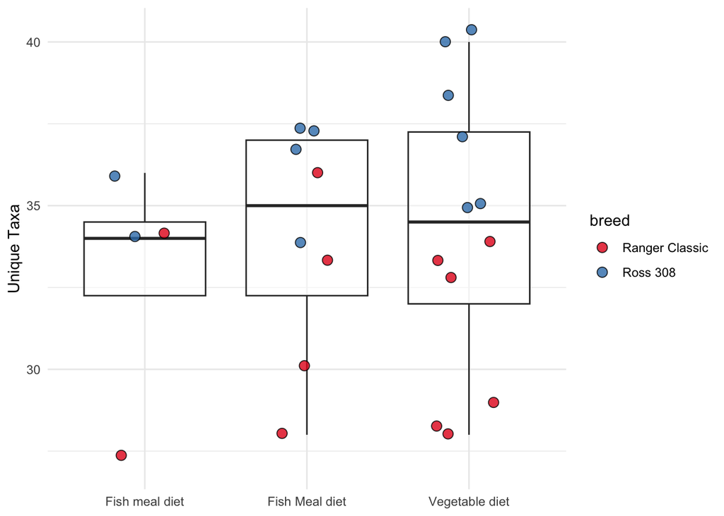

```r
# merging metadata with alpha metrics
meta_df <- microbiome::meta(ps)
plot_df_alpha <- cbind(stats_alpha, microbiome::meta(ps))

plot_df_alpha %>%
  ggplot(aes(y=observed, x=diet)) +
  geom_boxplot(alpha = 0.5, outlier.alpha = 0) +
  geom_point(
    aes(fill=breed),
    size = 3,
    alpha = 0.8,
    shape = 21,
    position = position_jitter(width = 0.2)
    ) +
  scale_color_brewer(palette = "Set1") +
  scale_fill_brewer(palette = "Set1") +
  labs(x = NULL, y = "Unique Taxa") +
  theme_minimal()
```

Next, you would typically proceed to perform some statistical analysis to quantify effect sizes, confidence intervals, and other parameters that are informative of covariate relevance.

### 2. Beta-Diversity

Beta-diversity measures the difference in species composition between different communities or habitats. This approach allows for the comparison of entire community profiles between samples, typically with some distance measure. Common distance metrics include the Aitchisons distance (Euclidean distance on CLR transfomred data), Bray-Curtis distance, Jaccard, Weighted and Unweightd Unifrac, see below for more info.

#### Aitchison’s Distance

Aitchison’s distance is commonly used for compositional data, where each element represents a proportion of a whole. This metric incorporates a log-ratio transformation to account for the compositional nature of the data.

$$\text{Aitchison's Distance} = \sqrt{\sum_{i=1}^{D} \left( \ln \frac{a_i}{g(a)} - \ln \frac{b_i}{g(b)} \right)^2}$$

Where $a_i$ and $b_i$ are the proportional abundances of species $i$ in two different communities, $D$ is the number of dimensions (species), and $g(x)$ is the geometric mean of the compositional vector $x$.

#### **Bray-Curtis Dissimilarity**

Bray-Curtis Dissimilarity accounts for the abundance of each species, measuring how dissimilar two communities are based on the counts of their constituent species.

$$\text{Bray-Curtis} = 1 - \frac{2 \times \sum_{i=1}^{S} \min(a_i, b_i)}{\sum_{i=1}^{S} (a_i + b_i)}$$

where $a_i$ and $b_i$ are the abundances of species $i$ in two different communities, and $S$ is the total number of species.

#### Jaccard Similarity Index

The Jaccard Similarity Index measures the similarity between two communities based solely on the presence or absence of species.

$$\text{Jaccard} = \frac{\text{Number of shared species}}{\text{Total number of unique species in both communities}}$$

#### UniFrac

UniFrac is a phylogenetic distance metric that measures the dissimilarity between two communities by considering the evolutionary branches that are unique to each community.

$$\text{UniFrac} = \frac{\text{Sum of branch lengths unique to either community}}{\text{Total branch lengths}}$$

#### Weighted UniFrac

Weighted UniFrac extends the UniFrac metric by incorporating the relative abundances of each species, thereby giving more weight to branches with more abundant species.

$$\text{Weighted UniFrac} = \frac{\sum_{i=1}^{B} w_i \cdot | a_i - b_i |}{\sum_{i=1}^{B} w_i}$$

where $w_i$ is the length of branch $i$ in the phylogenetic tree, and $a_i$ and $b_i$ are the relative abundances of the species corresponding to branch $i$ in the two communities. $B$ is the total number of branches.

Here we demonstrate an example of calculating the Aitchison’s distance using the `phyloseq::distance` function.

```r
# keep taxa that are present in at least two different samples in our sample set
ps_qc <- core(ps, detection = 0, prevalence = 2/24)
ps_qc
```

```
phyloseq-class experiment-level object
otu_table()   OTU Table:         [ 69 taxa and 24 samples ]
sample_data() Sample Data:       [ 24 samples by 46 sample variables ]
tax_table()   Taxonomy Table:    [ 69 taxa by 7 taxonomic ranks ]
```

```r
# perform CLR transformation
ps_qc_clr <- microbiome::transform(ps_qc, "clr")


# obtaining a distance matrix using Aitchisons distance (Euclidean distance on CLR transformed vars)
dist_matrix <- phyloseq::distance(ps_qc_clr, method = "euclidean")

# formating matrix into a long-tidy data table
dist_matrix %>%
  as.matrix() %>%
  as.data.frame() %>%
  rownames_to_column(var = "pair_1") %>%
  pivot_longer(!pair_1)
```

```
# A tibble: 576 × 3
   pair_1       name         value
   <chr>        <chr>        <dbl>
 1 MGYA00615918 MGYA00615918  0
 2 MGYA00615918 MGYA00615929  6.35
 3 MGYA00615918 MGYA00615930  6.13
 4 MGYA00615918 MGYA00615931  8.35
 5 MGYA00615918 MGYA00615932  6.64
 6 MGYA00615918 MGYA00615933  8.05
 7 MGYA00615918 MGYA00615934  6.65
 8 MGYA00615918 MGYA00615935  5.69
 9 MGYA00615918 MGYA00616693  7.57
10 MGYA00615918 MGYA00616694  7.15
# ℹ 566 more rows
```

We aggregated distance values across pairs of samples of interest using our metadata and the `usedist::dist_groups` function.

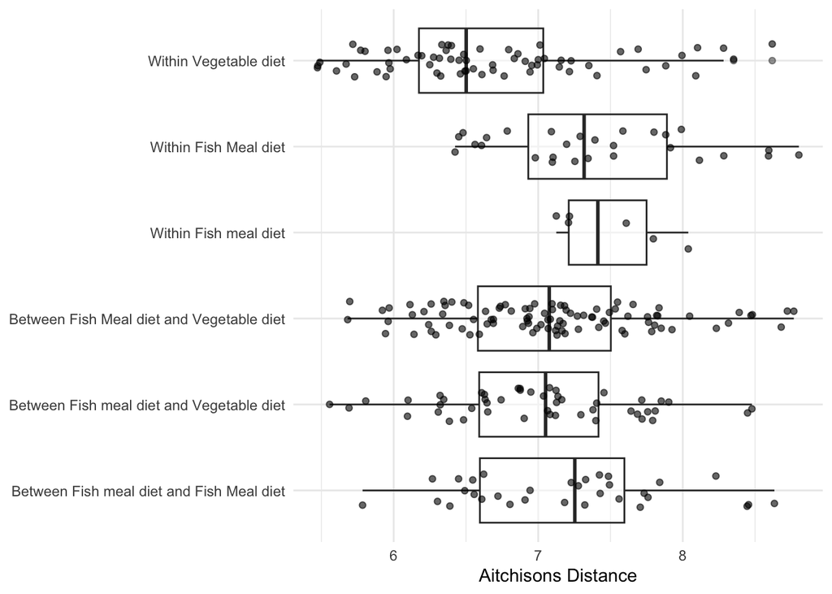

```r
group_dist <- usedist::dist_groups(dist_matrix, meta_df$diet)

group_dist %>%
  ggplot(aes(y=Label, x=Distance)) +
  geom_boxplot(alpha = 0.5) +
  geom_point(position = position_jitter(height = 0.2), alpha = 0.6) +
  labs( x = "Aitchisons Distance", y = NULL) +
  theme_minimal()
```

These distance metrics may also be visualized in reduced dimensionality such as via Principle Coordinate Analysis (PCoA), tSNE, UMAP, etc.

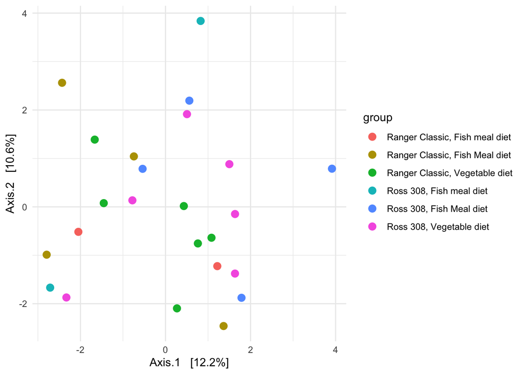

```r
ord <- phyloseq::ordinate(ps_qc_clr, "MDS", "euclidean")
plot_ordination(ps_qc_clr, ord, color = "group") +
  theme_minimal() +
  geom_point(size = 3)
```

### Association Testing (SIAMCAT)

see [documentation](https://siamcat.embl.de)

[output not shown]

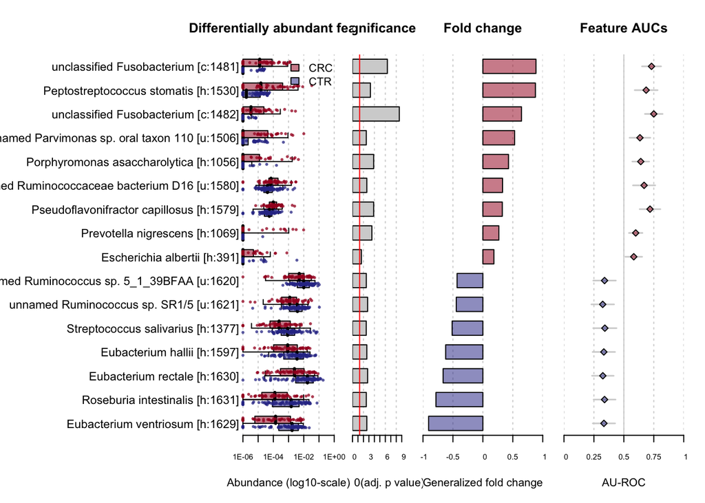

```r
data(siamcat_example)
association.plot(siamcat_example)
```

also see MaAsLin2 [documentation](https://github.com/biobakery/Maaslin2)

### Gene-Profile Analyses | Microbial Pathway Visualization

Pathway Visualization (EMBL tutorial available through MGnify)

```r
# Loading in KO Data
ko_data <- readRDS(
  glue("{wkdir}/data/interim/2023-10-09_KO-datatable.rds")
)
km_data <- readRDS(
  glue("{wkdir}/data/interim/2023-10-09_KM-datatable.rds")
)

# renaming the attributes.counts column (important for later)
ko_data <- dplyr::rename(ko_data, counts = attributes.count)

# removing Modules with low completeness
km_data <- km_data %>%
  filter(attributes.completeness > 95)
modules <- unique(km_data$attributes.accession)
modules
```

```
  [1] "M00001" "M00002" "M00003" "M00004" "M00005" "M00006" "M00007" "M00008"
  [9] "M00009" "M00010" "M00011" "M00012" "M00015" "M00016" "M00017" "M00018"
 [17] "M00019" "M00020" "M00021" "M00022" "M00023" "M00024" "M00025" "M00026"
 [25] "M00027" "M00028" "M00035" "M00045" "M00046" "M00048" "M00049" "M00050"
 [33] "M00051" "M00052" "M00053" "M00060" "M00061" "M00063" "M00064" "M00075"
 [41] "M00082" "M00083" "M00086" "M00087" "M00088" "M00093" "M00096" "M00115"
 [49] "M00116" "M00117" "M00118" "M00119" "M00120" "M00121" "M00122" "M00123"
 [57] "M00124" "M00125" "M00126" "M00127" "M00133" "M00136" "M00140" "M00144"
 [65] "M00149" "M00150" "M00153" "M00157" "M00159" "M00166" "M00168" "M00169"
 [73] "M00176" "M00307" "M00345" "M00364" "M00417" "M00432" "M00525" "M00526"
 [81] "M00527" "M00530" "M00532" "M00545" "M00549" "M00550" "M00552" "M00554"
 [89] "M00555" "M00570" "M00572" "M00579" "M00580" "M00627" "M00631" "M00632"
 [97] "M00651" "M00652" "M00696" "M00697" "M00745" "M00761" "M00793" "M00844"
[105] "M00846" "M00854" "M00855" "M00879" "M00880" "M00577" "M00878" "M00542"
[113] "M00533" "M00700" "M00866" "M00033" "M00151" "M00155" "M00365" "M00551"
[121] "M00565" "M00702" "M00704" "M00725" "M00726" "M00378" "M00134"
```

If there are custom pathway IDs you are interested in, enter them in the list below You can view these pathways here. Otherwise, the section below collects the most general and complete pathways.

```r
CUSTOM_PATHWAY_IDS <- list(
  "00010",
  "00020",
  "00030",
  "00061",
  "01232",
  "00240",
  "00190"
)


paste(
  "Using",
  CUSTOM_PATHWAY_IDS,
  " - ",
  sapply(CUSTOM_PATHWAY_IDS, function(id)
    paste(get_pathway_info(id)[1], " : ",
          get_pathway_info(id)[2])),
  "as a Custom Pathway"
)
```

```
[1] "Using 00010  -  Glycolysis / Gluconeogenesis  :  https://www.kegg.jp/pathway/map00010 as a Custom Pathway"
[2] "Using 00020  -  Citrate cycle (TCA cycle)  :  https://www.kegg.jp/pathway/map00020 as a Custom Pathway"
[3] "Using 00030  -  Pentose phosphate pathway  :  https://www.kegg.jp/pathway/map00030 as a Custom Pathway"
[4] "Using 00061  -  Fatty acid biosynthesis  :  https://www.kegg.jp/pathway/map00061 as a Custom Pathway"
[5] "Using 01232  -  Nucleotide metabolism  :  https://www.kegg.jp/pathway/map01232 as a Custom Pathway"
[6] "Using 00240  -  Pyrimidine metabolism  :  https://www.kegg.jp/pathway/map00240 as a Custom Pathway"
[7] "Using 00190  -  Oxidative phosphorylation  :  https://www.kegg.jp/pathway/map00190 as a Custom Pathway"
```

Function that collects KEGG pathways for a given list of IDs, excluding chemical structure & global maps

```r
collect_pathways <- function(ids_list) {
    pathways = list()
    for (id in ids_list) {
        current_pathway = as.list(keggLink("pathway", id))
        for (index in grep("map", current_pathway)) {
            clean_id = gsub("*path:", "", current_pathway[index])
            # Discarding chemical structure (map010XX), global (map011XX), and overview (map012XX) maps
            prefix = substring(clean_id, 1, 6)
            if(is.na(match("map010", prefix)) & is.na(match("map011", prefix)) & is.na(match("map012", prefix)) ){
                pathways = append(pathways, clean_id)
            }
        }
    }
    return(pathways)
}
```

Collecting Modules

```r
md_pathways = collect_pathways(modules)
head(md_pathways)
```

```
[[1]]
[1] "map00010"

[[2]]
[1] "map00010"

[[3]]
[1] "map00010"

[[4]]
[1] "map00020"

[[5]]
[1] "map00030"

[[6]]
[1] "map00030"
```

```r
# Counting the number of modules we have in each pathway
our_pathways_counts = list()
for (path_element in md_pathways) {
    if (path_element %in% names(our_pathways_counts)) {
        new_value = our_pathways_counts[[path_element]] + 1
        our_pathways_counts[path_element] = new_value
    } else {
        our_pathways_counts[path_element] = 1
    }
}

# Counting the number of modules expected in each pathway
u_pathways = unique(md_pathways)
exp_pathways_counts = list()
for (path in u_pathways) {
    mod_count = length(as.list(keggLink("module", path)))
    exp_pathways_counts[path] = mod_count
}

# Selecting the pathways having all their constituent modules. We remove the 'map' prefix as pathview doesn't like it
to_draw = list()
for (pathway in names(our_pathways_counts)) {
    our_value = our_pathways_counts[[pathway]]
    exp_value = exp_pathways_counts[[pathway]]
    ratio =  our_value / exp_value
    if (ratio == 1) {
        nude_id =  gsub("map", "", pathway)
        to_draw = append(to_draw, nude_id)
    }
}


# Adding the custom pathways to to_draw if not present already
for (pathway in CUSTOM_PATHWAY_IDS){
    if (!(pathway %in% to_draw)) {
    to_draw = append(to_draw, pathway)
        }
}

# printing name of the pathways to be drawn
for (pathway in to_draw){
    print(paste(pathway, "-->", get_pathway_info(pathway)[1]," : ",get_pathway_info(pathway)[2], sep=" "))
}
```

```
[1] "00010 --> Glycolysis / Gluconeogenesis  :  https://www.kegg.jp/pathway/map00010"
[1] "00340 --> Histidine metabolism  :  https://www.kegg.jp/pathway/map00340"
[1] "00650 --> Butanoate metabolism  :  https://www.kegg.jp/pathway/map00650"
[1] "00071 --> Fatty acid degradation  :  https://www.kegg.jp/pathway/map00071"
[1] "00480 --> Glutathione metabolism  :  https://www.kegg.jp/pathway/map00480"
[1] "00360 --> Phenylalanine metabolism  :  https://www.kegg.jp/pathway/map00360"
[1] "00430 --> Taurine and hypotaurine metabolism  :  https://www.kegg.jp/pathway/map00430"
[1] "01502 --> Vancomycin resistance  :  https://www.kegg.jp/pathway/map01502"
[1] "02020 --> Two-component system  :  https://www.kegg.jp/pathway/map02020"
[1] "00521 --> Streptomycin biosynthesis  :  https://www.kegg.jp/pathway/map00521"
[1] "00500 --> Starch and sucrose metabolism  :  https://www.kegg.jp/pathway/map00500"
[1] "00020 --> Citrate cycle (TCA cycle)  :  https://www.kegg.jp/pathway/map00020"
[1] "00030 --> Pentose phosphate pathway  :  https://www.kegg.jp/pathway/map00030"
[1] "00061 --> Fatty acid biosynthesis  :  https://www.kegg.jp/pathway/map00061"
[1] "01232 --> Nucleotide metabolism  :  https://www.kegg.jp/pathway/map01232"
[1] "00240 --> Pyrimidine metabolism  :  https://www.kegg.jp/pathway/map00240"
[1] "00190 --> Oxidative phosphorylation  :  https://www.kegg.jp/pathway/map00190"
```

Drawing maps!

```r
#|wwarning: false

# create a figures directory
pathway_fig_dir <- glue("{wkdir}/figures/pathways")
dir.create(pathway_fig_dir, recursive = TRUE, showWarnings = FALSE)

suppressMessages({
for (p in to_draw[1:10]) {
    pathview(gene.data = ko_data,
             species = "ko",
             pathway.id = p,
             bins=c(2, 2),
             both.dirs = FALSE,
             limit = c(1,1),
             mid = c("#ffffff" , "#ffffff"),
             high = c("#02b3ad" , "#02b3ad")
    )
}
})
# relocate pathview files to figure dir
list.files(
  glue("{wkdir}/notebooks"), pattern = "^ko", full.names =TRUE
) %>%
  fs::file_move(glue("{pathway_fig_dir}/{basename(.)}"))
```

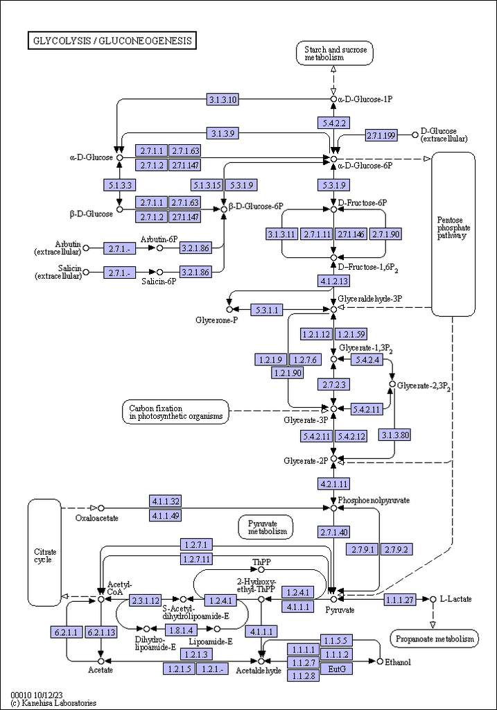

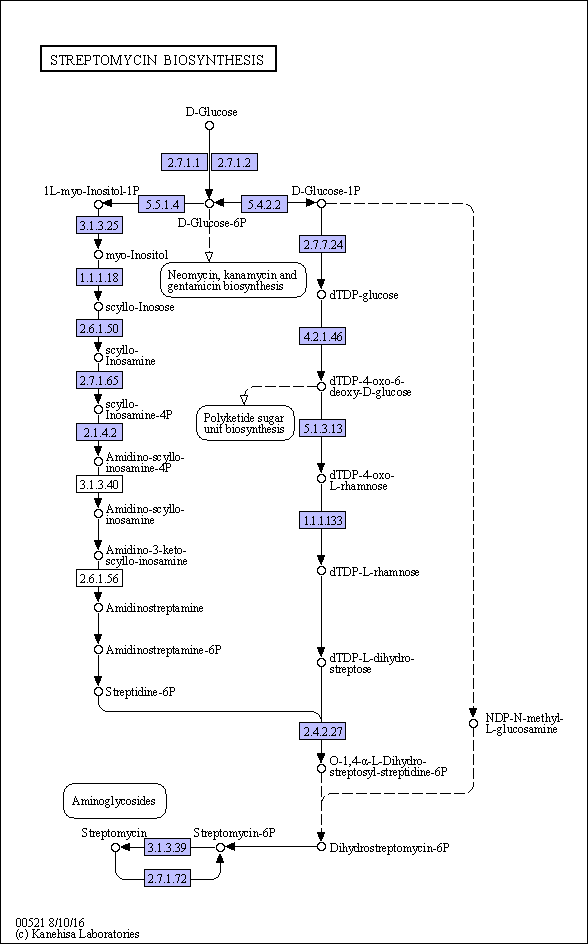